# How do the frequency and severity of global commercial aircraft safety incidents vary since the 1980s?

# Permissions

- [ ] YES - make available
- [ X ] NO - keep private

# Names

- Julianne Marc Tamayo
- Naomi Ortega
- Kiara Lizarraga
- Austin Yeung
- Alice Yu

# Abstract

This project investigated the frequency and severity of commercial aviation safety incidents since the 1980s to assess how the causes—human error, mechanical error, and weather—have changed over time. With recent news coverage in early 2025 highlighting airplane emergencies, examining aviation safety trends has become increasingly significant, as well as determining whether technological advances have reduced mechanical problems while human error remains as a persistent factor. We used datasets from the NTSB Accident Investigation Database and the Kaggle Airplane Crashes dataset to identify trends, categorize incidents, and compare fatality rates. Our findings showed that human error continues to be the dominant cause of events, and mechanical errors have steadily decreased since 2012. Additionally, adverse weather conditions persist in contributing to a substantial number of commercial airplane crashes, maintaining a steady pattern of frequency across the analyzed timespan. The results emphasize the need for continued attention to human factors and maintaining the rise in quality of mechanical components in aviation safety.

# Research Question

How do the frequency and severity of global commercial aircraft safety incidents (including accidents, serious incidents, and mechanical failures) vary since the 1980s?

Sub-question:

What proportion of commercial aircraft safety incidents can be attributed to human error versus mechanical failure, and how have these trends evolved over time?

## Background and Prior Work

The field of commercial aviation safety has achieved multiple improvements over the recent decades, establishing planes as among the safest ways of transportation worldwide. Recent research has demonstrated that commercial air travel continues to become significantly safer, with the risk of fatality dropping to approximately 1 per every 13.7 million passenger boardings during the 2018–2022 period <sup>1</sup>. The evolution of commercial aviation safety follows a consistent pattern of improvement, particularly evident in fatal accident rates <sup>2</sup>. In the early 1970s, there were approximately 6 fatal accidents per million flights. These numbers have been on a downward trend since then. MIT researchers have categorized countries into three distinct tiers based on their safety performance: First Tier, with approximately 1 death per 80 million boardings; 2nd Tier, with safety metrics similar to the First Tier (~1 per 80 million), and 3rd Tier, which have a fatality rate 36.5 times higher than the top tier. The United States belongs in the first tier along with countries Australia, Canada, and Japan <sup>1</sup>. However, even if the incidents have decreased over time, they still continue to occur and threaten the safety of commercial aviation, remaining a critical concern for the global travel industry. Understanding the factors behind safety incidents can help improve flight safety. Our research questions include the exploration of topics about the frequency and severity of these incidents and how they have evolved since the 21st century. We also want to investigate which aircraft components are most frequently involved and examine trends in incidents caused by human error versus mechanical failure to see if there are any visual patterns.

A lot of the annual reduction in accidents can be owed to technological advancements. For example, collision avoidance systems and advanced monitoring technologies have played a crucial role in improving safety metrics. However, human factors continue to be a critical area of focus. Several authoritative databases track aviation safety globally; these sources provide standardized metrics, enabling consistent tracking of safety trends over time. Numerous studies explore aviation safety using large datasets, including the Aviation Safety Network (ASN) and National Transportation Safety Board (NTSB) databases, which track global accidents and incidents <sup>3</sup>. For example, the Aviation Safety Reporting System (ASRS) collects reports from aviation professionals and has been crucial in identifying human factors and mechanical issues in incidents.

Despite remarkable progress, challenges remain, particularly in addressing persistent human error factors, implementing emerging technologies effectively, and maintaining consistent global safety standards. In this project, we aim to perform a comprehensive data analysis to explore safety incident trends since 2000, examine the relationship between component failures and the severity of accidents, and analyze the distinct roles that human and mechanical factors play in influencing safety outcomes. In data science, predictive modeling has been used to forecast accident rates based on weather, aircraft models, and other factors. More recently, machine learning techniques have helped uncover patterns in large datasets, while natural language processing (NLP) has been used to analyze incident reports. Notable projects like the Global Aviation Safety Network (GASN) apply advanced analytics to identify trends and improve aviation safety. Our research builds on these efforts, we aim to apply statistical analysis and data visualization to existing datasets, contributing insights into how incidents are evolving and which factors are most influential.

1. ^ Dizikes, Peter. “Study: Flying Keeps Getting Safer.” MIT News | Massachusetts Institute of Technology, Aug. 2024, news.mit.edu/2024/study-flying-keeps-getting-safer-0807.
2. ^ Ortiz-Ospina, Esteban. “Commercial Flights Have Become Significantly Safer in Recent Decades.” Our World in Data, 2024, ourworldindata.org/data-insights/commercial-flights-have-become-significantly-safer-in-recent-decades.
3. ^ Shappell, Scott, et al. Human Error and Commercial Aviation Accidents: A Human Error and Commercial Aviation Accidents: A Comprehensive, Fine-Grained Analysis Using HFACS Comprehensive, Fine-Grained Analysis Using HFACS Part of the Aviation Safety and Security Commons, and the Human Factors Psychology Commons Scholarly Commons Citation Scholarly Commons Citation. 2006.

# Hypothesis

Our hypothesis is that there has been a decline in mechanical failures throughout time due to the advancements in technology. Additionally, we predict that there has been no change in the rate of plane crashes caused by pilot error. Finally, we predict that there has been no change in crashes caused by weather due to weather being a natural component which people cannot control for.

# Data

## Data overview

**Dataset #1**

- Dataset Name: NTSB Accident Investigation Database
- Link to the dataset: https://www.ntsb.gov/Pages/ResultsV2.aspx?queryId=a0ca4805-de9d-4653-ac57-2b2af7027a5c
- Number of observations: 2626
- Total number of variables in the dataset: 38
- Number of variables used: 11

- EventDate (datetime64): date of the crash
- HighestInjuryLevel (string): whether the highest injury level of people onboard was minor, serious, or fatal
- FatalInjuryCount (int64): number of fatal injuries
- SeriousInjuryCount (int64): number of serious injuries (requiring hospitalization over 48 hours, breaking bones, burns, etc)
- MinorInjuryCount (int64): number of minor injuries
- ProbableCause(string): cause of the crash
- Make (string): make of the airplane that crashed
- Model (string): model of the airplane that crashed
- AirCraftDamage (string): whether the airplane was damaged seriously, minorly, or destroyed
- WeatherCondition (string): weather condition during the flight, where IMC indicates poor visibility resulting in pilot utilizing flight instruments
- Operator (string): flight airline

**Dataset #2**

The 5 important variables in this dataset are:

- Date (datetime64): date of the crash
- Operator (string): flight airline
- Aboard (int64): total number of people on the plane
- Fatalities (int64): Number of people aboard who died
- Summary (string): cause of the crash

## Dataset #1 NTSB Accident Investigation Database

```python
"""Import necessary packages and modules"""
import pandas as pd
from collections import Counter
import matplotlib.pyplot as plt
import seaborn as sns
import numpy as np
import seaborn.objects as so
from scipy.stats import ttest_ind, chisquare, normaltest
```

```python
"""Read in the dataset"""
commercialflights = pd.read_csv('ntsb_dataset.csv')
```

First, we will do some cleaning of the NTSB data to remove information not necessary to our analysis, and to get our variables into a workable format.

```python
## Removes unscheduled flights from the dataframe.
commercialflights = commercialflights[commercialflights['Scheduled']=='SCHD']
```

```python
# Converts dates in the 'EventDate' column to date time objects.
commercialflights['EventDate'] = pd.to_datetime(commercialflights['EventDate'])
```

```python
commercialflights
```

|  | NtsbNo | EventType | Mkey | EventDate | City | State | Country | ReportNo | N | HasSafetyRec | ... | PurposeOfFlight | FAR | AirCraftDamage | WeatherCondition | Operator | ReportStatus | RepGenFlag | DocketUrl | DocketPublishDate | Unnamed: 37 |
| --- | --- | --- | --- | --- | --- | --- | --- | --- | --- | --- | --- | --- | --- | --- | --- | --- | --- | --- | --- | --- | --- |
| 0 | DCA24LA290 | ACC | 194995 | 2024-08-19 13:45:00+00:00 | Highland Meadows | New Mexico | United States | NaN | N7734H | False | ... | NaN | 121 | NaN | VMC | SOUTHWEST AIRLINES CO | Completed | False | https://data.ntsb.gov/Docket?ProjectID=194995 | 1/16/2025 7:00:00 PM | NaN |
| 1 | DCA24WA260 | INC | 194899 | 2024-08-10 09:16:00+00:00 | Geneva | NaN | Switzerland | NaN | N659UA | False | ... | NaN | 121 | NaN | NaN | United Airlines | NaN | False | NaN | NaN | NaN |
| 2 | DCA24LA255 | ACC | 194881 | 2024-08-08 18:17:00+00:00 | Waycross | Georgia | United States | NaN | N542UW | False | ... | NaN | 121 | NaN | VMC | AMERICAN AIRLINES INC | Completed | False | https://data.ntsb.gov/Docket?ProjectID=194881 | 1/16/2025 7:00:00 PM | NaN |
| 3 | DCA24LA256 | ACC | 194882 | 2024-08-07 14:30:00+00:00 | Severn | Maryland | United States | NaN | N226WN | False | ... | NaN | 121 | NaN | VMC | SOUTHWEST AIRLINES CO | Completed | False | https://data.ntsb.gov/Docket?ProjectID=194882 | 10/28/2024 6:00:00 PM | NaN |
| 4 | DCA24LA254 | ACC | 194848 | 2024-08-03 22:56:00+00:00 | Linneus | Missouri | United States | NaN | N793AN | False | ... | NaN | 121 | NaN | VMC | AMERICAN AIRLINES INC | Completed | False | https://data.ntsb.gov/Docket?ProjectID=194848 | 1/16/2025 7:00:00 PM | NaN |
| ... | ... | ... | ... | ... | ... | ... | ... | ... | ... | ... | ... | ... | ... | ... | ... | ... | ... | ... | ... | ... | ... |
| 2228 | DCA82AA013 | ACC | 70009 | 1982-01-23 20:37:00+00:00 | BOSTON | Massachusetts | United States | NaN | N113WA | True | ... | UNK | 121 | Destroyed | IMC | WORLD AIRWAYS, INC. | Completed | False | NaN | NaN | NaN |
| 2229 | ATL82IA041 | INC | 71495 | 1982-01-22 09:55:00+00:00 | LOUISVILLE | Kentucky | United States | NaN | N18FE | False | ... | UNK | 121 | NaN | VMC | FEDERAL EXPRESS CORPORATION | Completed | False | NaN | NaN | NaN |
| 2230 | DCA82AA011 | ACC | 69192 | 1982-01-13 17:01:00+00:00 | WASHINGTON | District of Columbia | United States | NaN | N62AF | True | ... | UNK | 121 | Destroyed | IMC | AIR FLORIDA, INC | Completed | False | NaN | NaN | NaN |
| 2231 | DCA82AA011 | ACC | 79455 | 1982-01-13 05:00:00+00:00 | WASHINGTON | District of Columbia | United States | AAR8208 | N62AF | True | ... | UNK | 121 | Destroyed | IMC | AIR FLORIDA, INC | Completed | True | NaN | NaN | NaN |
| 2232 | CHI82IA026 | INC | 70223 | 1982-01-12 19:30:00+00:00 | CHICAGO | Illinois | United States | NaN | N31031 | False | ... | UNK | 121 | NaN | Unknown | TRANS WORLD AIRLINES | Completed | False | NaN | NaN | NaN |

2215 rows × 38 columns

```python
def drop_cols(commercialflights):
    """
    A function that cleans dataset 1 of columns and null values in the ProbableCause column.
    """
    commercialflights.shape
    commercialflights= commercialflights[['EventDate','HighestInjuryLevel', 'FatalInjuryCount',
                                          'SeriousInjuryCount', 'MinorInjuryCount', 'ProbableCause',
                                          'Make', 'Model','AirCraftDamage',
                                          'WeatherCondition', 'Operator']]
    commercialflights = commercialflights.dropna(axis=0, subset="ProbableCause")
    commercialflights.shape
    return commercialflights
```

Calling this function keeps only relevant columns in the dataframe and discards any incident without probable cause, since we wouldn't be able to categorize those incidents.

```python
#Function Call
commercialflights = drop_cols(commercialflights)
```

```python
commercialflights
```

|  | EventDate | HighestInjuryLevel | FatalInjuryCount | SeriousInjuryCount | MinorInjuryCount | ProbableCause | Make | Model | AirCraftDamage | WeatherCondition | Operator |
| --- | --- | --- | --- | --- | --- | --- | --- | --- | --- | --- | --- |
| 0 | 2024-08-19 13:45:00+00:00 | Serious | 0 | 1 | 0 | An encounter with convectively induced turbule... | BOEING | 737 | NaN | VMC | SOUTHWEST AIRLINES CO |
| 2 | 2024-08-08 18:17:00+00:00 | Serious | 0 | 1 | 3 | The aircraft’s encounter with convectively ind... | AIRBUS | A321-231 | NaN | VMC | AMERICAN AIRLINES INC |
| 3 | 2024-08-07 14:30:00+00:00 | Serious | 0 | 1 | 0 | A passenger’s failure to comply with crew memb... | BOEING | 737 | NaN | VMC | SOUTHWEST AIRLINES CO |
| 4 | 2024-08-03 22:56:00+00:00 | Serious | 0 | 1 | 2 | An inadvertent encounter with convectively ind... | BOEING | 777-223 | NaN | VMC | AMERICAN AIRLINES INC |
| 5 | 2024-07-16 23:16:00+00:00 | Serious | 0 | 1 | 1 | The captain’s inadvertent aggressive applicati... | AIRBUS | A320-232 | NaN | VMC | Spirit Airlines Inc. |
| ... | ... | ... | ... | ... | ... | ... | ... | ... | ... | ... | ... |
| 1888 | 1987-12-03 13:34:00+00:00 | NaN | 0 | 0 | 0 | IMPROPER DRILLING OF THE CROSS HOLE IN THE SLA... | BOEING | 727-243 | Minor | VMC | NaN |
| 1900 | 1987-10-09 12:05:00+00:00 | NaN | 0 | 0 | 0 | FAILURE OF THE GENERAL AVIATION AIRCRAFT TO VI... | MCDONNELL DOUGLAS | DC-9-82 | NaN | VMC | AMERICAN AIRLINES, INC. |
| 1905 | 1987-09-28 15:43:00+00:00 | Serious | 0 | 1 | 39 | ENCOUNTER WITH UNDETECTABLE CLEAR AIR TURBULENCE. | LOCKHEED | L-1011 | Minor | VMC | EASTERN AIRLINES |
| 1924 | 1987-06-22 20:39:00+00:00 | NaN | 0 | 0 | 0 | FAILURE OF THE QUALIFIED MECHANIC TO INSURE TH... | BOEING, BOEING | 737-277, 747SP | Substantial,Substantial | Unknown | AMERICA WEST AIRLINES,UNITED AIRLINES |
| 1947 | 1987-02-27 21:00:00+00:00 | NaN | 0 | 0 | 0 | FAILURE OF COMPANY MAINTENANCE PERSONNEL TO AD... | BRITISH AEROSPACE | BA146-200A | Substantial | VMC | PACIFIC SOUTHWEST AIRLINES |

1673 rows × 11 columns

One important step to prepare our data for analysis is that we need to categorize the description of the probable cause for each crash into our categories of interest: weather, human error, and mechanical error. To do so, we first prepare the text by converting it into a format that can be cleaned.

```python
def clean_text(text):
    """
    Cleans the text by removing punctuation and splitting it into words. Converts everything to lowercase.
    """
    punctuation_chars = ".,!?;:'\"()[]{}<>-/_&"

    # Replace punctuation with spaces
    for char in punctuation_chars:
        text = text.replace(char, ' ')

    # Convert text to lowercase and split into words
    words = text.lower().split()
    return words
```

Next, we identify words that appear very often in the probable causes that need to be removed because they are not informative for our purposes of categorizing the crashes by their cause.

```python
# List of common words to exclude (stop words)
# Stop words determined first via common word articles
# Then running the functions, manually adding more words that are not causes, e.g. 'during' and 'resulted'

stop_words = set([
    # the following are filler words
    'the', 'a', 'an', 'and', 'in', 'on', 'or', 'at', 'of', 'to', 'for', 'with', 'about', 'as', 'by', 'this', 'that', 's', 'was', 'which', 'during', 'resulted', 'from', 'were', 'due', 'his',
    'subsequent', 'clear', 'between', 'when', 'use', 'their', 'caused', 'being', 'after', 'into',
    # the words below are usually found in explanations but they are not the causes
    'contributing', 'airplane', 'flight', 'accident', 'aircraft', 'not', 'factor', 'factors', 'resulting', 'failure', 'inadequate', 'inadvertent', 'encounter', 'landing',
    'incident', 'control', 'improper', 'right', 'left', 'company', 'system', 'while', 'lack', 'maintain', 'approach', 'takeoff', 'main', 'loss', 'fatigue', 'follow',
    'runway', 'procedures', 'injury', 'ground', 'clearance', 'fatigue', 'first', 'tug', 'inspection', 'manufacturer', 'collision', '1', 'undetermined', 'area', 'serious',
    '2', 'cabin', 'descent', 'door', 'local', 'airport', 'adequate', 'excessive', 'visual', 'high', 'information', 'reasons', 'proper', 'damage',
    # this word is a type of turbulence
    'convective'
])
```

Now we can remove the unneeded words to reduce each cause to their key words.

```python
def process_row(text, stop_words):
    """
    Processes a single row of text by cleaning and filtering out stop words. Returns a list of words.
    """
    # Clean the text and split it into words
    words = clean_text(text)

    # Filter out stop words
    filtered_words = [word for word in words if word not in stop_words]

    return filtered_words
```

```python
commercialflights['ProbableCause'] = commercialflights['ProbableCause'].apply(lambda x: ' '.join(process_row(str(x), stop_words)))
```

Now that we are left with words that indicate how each crash occurred, let's take a look at the most common words that occur in the crash descriptions.

```python
def count_top_words(csv_file, column_name, top_n):
    """
    Reads CSV file row by row, processes the specified column to count word frequencies
    excluding stop words, and returns the top N most common words.
    The results will be used in categorizing incident causes for data analysis.
    """
    # Initialize a Counter to count word frequencies
    word_counts = Counter()

    # Clean dataset using previously-defined drop_cols function
    cleaned = drop_cols(commercialflights)

    for text in commercialflights[column_name].dropna():
        filtered_words = process_row(str(text), stop_words)
        word_counts.update(filtered_words)

    # Get the top N most common words
    most_common_words = word_counts.most_common(top_n)

    return most_common_words
```

```python
column_name = 'ProbableCause'
top_n = 30  # Number of top words we want to see

# Get top N most common words
most_repeated = count_top_words(commercialflights, column_name, top_n)

# Display result
most_repeated
```

```
[('turbulence', 364),
 ('crew', 265),
 ('engine', 263),
 ('gear', 204),
 ('maintenance', 189),
 ('personnel', 160),
 ('air', 156),
 ('attendant', 147),
 ('captain', 145),
 ('pilot', 133),
 ('fuel', 121),
 ('controller', 113),
 ('separation', 107),
 ('fire', 93),
 ('operator', 91),
 ('pressure', 86),
 ('driver', 85),
 ('conditions', 83),
 ('hydraulic', 82),
 ('traffic', 77),
 ('passenger', 76),
 ('fan', 75),
 ('service', 74),
 ('nose', 73),
 ('weather', 73),
 ('power', 73),
 ('decision', 64),
 ('blade', 62),
 ('turbine', 62),
 ('officer', 58)]
```

```python
commercialflights
```

|  | EventDate | HighestInjuryLevel | FatalInjuryCount | SeriousInjuryCount | MinorInjuryCount | ProbableCause | Make | Model | AirCraftDamage | WeatherCondition | Operator |
| --- | --- | --- | --- | --- | --- | --- | --- | --- | --- | --- | --- |
| 0 | 2024-08-19 13:45:00+00:00 | Serious | 0 | 1 | 0 | convectively induced turbulence | BOEING | 737 | NaN | VMC | SOUTHWEST AIRLINES CO |
| 2 | 2024-08-08 18:17:00+00:00 | Serious | 0 | 1 | 3 | aircraft’s convectively induced turbulence | AIRBUS | A321-231 | NaN | VMC | AMERICAN AIRLINES INC |
| 3 | 2024-08-07 14:30:00+00:00 | Serious | 0 | 1 | 0 | passenger’s comply crew member instructions re... | BOEING | 737 | NaN | VMC | SOUTHWEST AIRLINES CO |
| 4 | 2024-08-03 22:56:00+00:00 | Serious | 0 | 1 | 2 | convectively induced turbulence cruise | BOEING | 777-223 | NaN | VMC | AMERICAN AIRLINES INC |
| 5 | 2024-07-16 23:16:00+00:00 | Serious | 0 | 1 | 1 | captain’s aggressive application brakes taxi s... | AIRBUS | A320-232 | NaN | VMC | Spirit Airlines Inc. |
| ... | ... | ... | ... | ... | ... | ... | ... | ... | ... | ... | ... |
| 1888 | 1987-12-03 13:34:00+00:00 | NaN | 0 | 0 | 0 | drilling cross hole slat track bearing bolt le... | BOEING | 727-243 | Minor | VMC | NaN |
| 1900 | 1987-10-09 12:05:00+00:00 | NaN | 0 | 0 | 0 | general aviation visually identify transport f... | MCDONNELL DOUGLAS | DC-9-82 | NaN | VMC | AMERICAN AIRLINES, INC. |
| 1905 | 1987-09-28 15:43:00+00:00 | Serious | 0 | 1 | 39 | undetectable air turbulence | LOCKHEED | L-1011 | Minor | VMC | EASTERN AIRLINES |
| 1924 | 1987-06-22 20:39:00+00:00 | NaN | 0 | 0 | 0 | qualified mechanic insure operation brakes pri... | BOEING, BOEING | 737-277, 747SP | Substantial,Substantial | Unknown | AMERICA WEST AIRLINES,UNITED AIRLINES |
| 1947 | 1987-02-27 21:00:00+00:00 | NaN | 0 | 0 | 0 | maintenance personnel adequately examine engin... | BRITISH AEROSPACE | BA146-200A | Substantial | VMC | PACIFIC SOUTHWEST AIRLINES |

1673 rows × 11 columns

Dataset #1 is now ready to be used for analysis.

## Dataset #2 Kaggle Airplane Crashes and Fatalities

```python
#read dataset 2
overallflights = pd.read_csv('kaggle_dataset.csv')
```

Now we will do some cleaning of the Kaggle dataset.

```python
# Converts dates in the 'Date' column to date time objects.
overallflights['Date'] = pd.to_datetime(overallflights['Date'])
```

```python
overallflights
```

|  | index | Date | Time | Location | Operator | Flight # | Route | Type | Registration | cn/In | Aboard | Fatalities | Ground | Summary |
| --- | --- | --- | --- | --- | --- | --- | --- | --- | --- | --- | --- | --- | --- | --- |
| 0 | 0 | 1908-09-17 | 17:18 | Fort Myer, Virginia | Military - U.S. Army | NaN | Demonstration | Wright Flyer III | NaN | 1 | 2.0 | 1.0 | 0.0 | During a demonstration flight, a U.S. Army fly... |
| 1 | 1 | 1912-07-12 | 06:30 | AtlantiCity, New Jersey | Military - U.S. Navy | NaN | Test flight | Dirigible | NaN | NaN | 5.0 | 5.0 | 0.0 | First U.S. dirigible Akron exploded just offsh... |
| 2 | 2 | 1913-08-06 | NaN | Victoria, British Columbia, Canada | Private | - | NaN | Curtiss seaplane | NaN | NaN | 1.0 | 1.0 | 0.0 | The first fatal airplane accident in Canada oc... |
| 3 | 3 | 1913-09-09 | 18:30 | Over the North Sea | Military - German Navy | NaN | NaN | Zeppelin L-1 (airship) | NaN | NaN | 20.0 | 14.0 | 0.0 | The airship flew into a thunderstorm and encou... |
| 4 | 4 | 1913-10-17 | 10:30 | Near Johannisthal, Germany | Military - German Navy | NaN | NaN | Zeppelin L-2 (airship) | NaN | NaN | 30.0 | 30.0 | 0.0 | Hydrogen gas which was being vented was sucked... |
| ... | ... | ... | ... | ... | ... | ... | ... | ... | ... | ... | ... | ... | ... | ... |
| 5263 | 5263 | 2009-05-20 | 06:30 | Near Madiun, Indonesia | Military - Indonesian Air Force | NaN | Jakarta - Maduin | Lockheed C-130 Hercules | A-1325 | 1982 | 112.0 | 98.0 | 2.0 | While on approach, the military transport cras... |
| 5264 | 5264 | 2009-05-26 | NaN | Near Isiro, DemocratiRepubliCongo | Service Air | NaN | Goma - Isiro | Antonov An-26 | 9Q-CSA | 5005 | 4.0 | 4.0 | NaN | The cargo plane crashed while on approach to I... |
| 5265 | 5265 | 2009-06-01 | 00:15 | AtlantiOcean, 570 miles northeast of Natal, Br... | Air France | 447 | Rio de Janeiro - Paris | Airbus A330-203 | F-GZCP | 660 | 228.0 | 228.0 | 0.0 | The Airbus went missing over the AtlantiOcean ... |
| 5266 | 5266 | 2009-06-07 | 08:30 | Near Port Hope Simpson, Newfoundland, Canada | Strait Air | NaN | Lourdes de BlanSablon - Port Hope Simpson | Britten-Norman BN-2A-27 Islander | C-FJJR | 424 | 1.0 | 1.0 | 0.0 | The air ambulance crashed into hills while att... |
| 5267 | 5267 | 2009-06-08 | NaN | State of Arunachal Pradesh, India | Military - Indian Air Force | NaN | Mechuka for Jorhat | Antonov An-32 | NaN | NaN | 13.0 | 13.0 | 0.0 | The military transport went missing while en r... |

5268 rows × 14 columns

```python
#Drops all crashes from before 1982 to align with the start of the commercialflights dataset.
overallflights = overallflights.loc[overallflights['Date'] >= '1982-01-12']
overallflights = overallflights.sort_values(by = 'Date')

#words we do not want
noncommercialwords = ['charter', 'helicopter', 'cargo plane']

#applying the data to exclude noncommercial flights due to words found
overallflights = overallflights[~overallflights['Summary'].str.contains('|'.join(noncommercialwords), case=False, na=False)]
```

```python
overallflights
```

|  | index | Date | Time | Location | Operator | Flight # | Route | Type | Registration | cn/In | Aboard | Fatalities | Ground | Summary |
| --- | --- | --- | --- | --- | --- | --- | --- | --- | --- | --- | --- | --- | --- | --- |
| 3329 | 3329 | 1982-01-13 | 16:01 | Washington, D.C. | Air Florida | 90 | Washington D.C. - Fort Lauderdale, FL | Boeing B-737-222 | N62AF | 19556/130 | 79.0 | 74.0 | 4.0 | The aircraft crashed into the 14th St. bridge ... |
| 3330 | 3330 | 1982-01-14 | NaN | Near Addis Ababa, Ethiopia | Military - Ethiopian Air Force | NaN | NaN | Antonov AN-26 | 71383 | NaN | 73.0 | 73.0 | 0.0 | Shot down by rebel forces. |
| 3331 | 3331 | 1982-01-23 | 19:36 | Logan Airport, Boston, Massachusett | World Airways | 30H | Newark, NJ - Boston, MA | McDonnell Douglas DC-10-30CF | N113WA | 47821/320 | 212.0 | 2.0 | 0.0 | While landing on an icy runway, the aircraft t... |
| 3332 | 3332 | 1982-01-25 | NaN | Constanta, Romania | Tarom | NaN | Training | Antonov An-24RV | YR-BMD | 57310202 | 7.0 | 7.0 | 0.0 | A malfunction of the No. 1 engine feathering s... |
| 3333 | 3333 | 1982-02-03 | 07:30 | Djibouti, Djbouti | Military - French Air Force | NaN | NaN | Nord 2501 Noratlas | 140/88JA | 140 | 35.0 | 35.0 | 0.0 | Crashed into a mountain before a planned parat... |
| ... | ... | ... | ... | ... | ... | ... | ... | ... | ... | ... | ... | ... | ... | ... |
| 5261 | 5261 | 2009-04-29 | 06:00 | Massamba, DemocratiRepubliof Congo | Bako Air | NaN | Bangui, CAR- Brazzaville, Congo - Harare, Zimb... | Boeing B-737-200 | TL-ADM | 22264/753 | 7.0 | 7.0 | 0.0 | Crashed while en route on a ferrying flight. T... |
| 5263 | 5263 | 2009-05-20 | 06:30 | Near Madiun, Indonesia | Military - Indonesian Air Force | NaN | Jakarta - Maduin | Lockheed C-130 Hercules | A-1325 | 1982 | 112.0 | 98.0 | 2.0 | While on approach, the military transport cras... |
| 5265 | 5265 | 2009-06-01 | 00:15 | AtlantiOcean, 570 miles northeast of Natal, Br... | Air France | 447 | Rio de Janeiro - Paris | Airbus A330-203 | F-GZCP | 660 | 228.0 | 228.0 | 0.0 | The Airbus went missing over the AtlantiOcean ... |
| 5266 | 5266 | 2009-06-07 | 08:30 | Near Port Hope Simpson, Newfoundland, Canada | Strait Air | NaN | Lourdes de BlanSablon - Port Hope Simpson | Britten-Norman BN-2A-27 Islander | C-FJJR | 424 | 1.0 | 1.0 | 0.0 | The air ambulance crashed into hills while att... |
| 5267 | 5267 | 2009-06-08 | NaN | State of Arunachal Pradesh, India | Military - Indian Air Force | NaN | Mechuka for Jorhat | Antonov An-32 | NaN | NaN | 13.0 | 13.0 | 0.0 | The military transport went missing while en r... |

1613 rows × 14 columns

This dataset includes flights that are not commercial, so we want to remove any flight that is military, mail delivery, or air taxi.

```python
#Function: drop rows with military, mail, air taxi values in the operator column.

def drop_specific_operators(df):
    keywords = ["military", "mail", "air taxi"]
    df = df.dropna(subset=["Operator"])  # Ensure 'Operator' column has no NaN values
    pattern = '|'.join(keywords)  # Create a regex pattern from keywords
    filtered_df = df[~df["Operator"].str.contains(pattern, case=False, na=False)] #Case-insensitive filtering
    return filtered_df

#apply to dataset
overallflights = drop_specific_operators(overallflights)
```

```python
overallflights
```

|  | index | Date | Time | Location | Operator | Flight # | Route | Type | Registration | cn/In | Aboard | Fatalities | Ground | Summary |
| --- | --- | --- | --- | --- | --- | --- | --- | --- | --- | --- | --- | --- | --- | --- |
| 3329 | 3329 | 1982-01-13 | 16:01 | Washington, D.C. | Air Florida | 90 | Washington D.C. - Fort Lauderdale, FL | Boeing B-737-222 | N62AF | 19556/130 | 79.0 | 74.0 | 4.0 | The aircraft crashed into the 14th St. bridge ... |
| 3331 | 3331 | 1982-01-23 | 19:36 | Logan Airport, Boston, Massachusett | World Airways | 30H | Newark, NJ - Boston, MA | McDonnell Douglas DC-10-30CF | N113WA | 47821/320 | 212.0 | 2.0 | 0.0 | While landing on an icy runway, the aircraft t... |
| 3332 | 3332 | 1982-01-25 | NaN | Constanta, Romania | Tarom | NaN | Training | Antonov An-24RV | YR-BMD | 57310202 | 7.0 | 7.0 | 0.0 | A malfunction of the No. 1 engine feathering s... |
| 3336 | 3336 | 1982-02-09 | 08:47 | Tokyo, Japan | Japan Air Lines | 350 | Fukuoka - Tokyo | McDonnell Douglas DC-8-61 | JA-8061 | 45889/291 | 174.0 | 24.0 | 0.0 | The aircraft flew into shallow water, 100 yard... |
| 3337 | 3337 | 1982-02-09 | NaN | Mt. Ipao, Philippines | Trans Air Services | NaN | Manila - Sicogon | Douglas DC-3 (C-47A-70-DL) | RP-C141 | 19251 | 32.0 | 3.0 | 0.0 | Struck Mt. Ipao on Panay Island. |
| ... | ... | ... | ... | ... | ... | ... | ... | ... | ... | ... | ... | ... | ... | ... |
| 5259 | 5259 | 2009-04-17 | 10:30 | Mount Gergaji, Indonesia | Mimika Air | 514 | Ilaga - Mulia | Pilatus PC-6 | PK-LTJ | 959 | 11.0 | 11.0 | 0.0 | The passenger plane crashed in poor weather in... |
| 5260 | 5260 | 2009-04-17 | 15:32 | Canaima National Park, Venezuela | Aerotuy airline | NaN | Canaima - Porlamar | Cessna 208B Grand Caravan | YV-1181 | 208B-0695 | 11.0 | 1.0 | 0.0 | The plane, carrying 9 tourists, crashed 5 mile... |
| 5261 | 5261 | 2009-04-29 | 06:00 | Massamba, DemocratiRepubliof Congo | Bako Air | NaN | Bangui, CAR- Brazzaville, Congo - Harare, Zimb... | Boeing B-737-200 | TL-ADM | 22264/753 | 7.0 | 7.0 | 0.0 | Crashed while en route on a ferrying flight. T... |
| 5265 | 5265 | 2009-06-01 | 00:15 | AtlantiOcean, 570 miles northeast of Natal, Br... | Air France | 447 | Rio de Janeiro - Paris | Airbus A330-203 | F-GZCP | 660 | 228.0 | 228.0 | 0.0 | The Airbus went missing over the AtlantiOcean ... |
| 5266 | 5266 | 2009-06-07 | 08:30 | Near Port Hope Simpson, Newfoundland, Canada | Strait Air | NaN | Lourdes de BlanSablon - Port Hope Simpson | Britten-Norman BN-2A-27 Islander | C-FJJR | 424 | 1.0 | 1.0 | 0.0 | The air ambulance crashed into hills while att... |

1228 rows × 14 columns

The dataset still contains a lot of variables we will not be using, so we will remove those now. We also need to add a column containing the percentage of fatalities that occured out of the total number of people aboard each flight.

```python
#Function: drop columns, drops all aside from the 5 wanted, and calculates percentage of fatalities and adds that column

def drop_cols2(overallflights):
	overallflights = overallflights[['Date', 'Operator', 'Aboard', 'Fatalities', 'Summary']]
	overallflights = overallflights.assign(FatalitiesPercent =  overallflights['Fatalities']/ overallflights['Aboard'].replace(0, 1))
	return overallflights

#Drop col 2 funct
overallflights = drop_cols2(overallflights)
```

```python
overallflights
```

|  | Date | Operator | Aboard | Fatalities | Summary | FatalitiesPercent |
| --- | --- | --- | --- | --- | --- | --- |
| 3329 | 1982-01-13 | Air Florida | 79.0 | 74.0 | The aircraft crashed into the 14th St. bridge ... | 0.936709 |
| 3331 | 1982-01-23 | World Airways | 212.0 | 2.0 | While landing on an icy runway, the aircraft t... | 0.009434 |
| 3332 | 1982-01-25 | Tarom | 7.0 | 7.0 | A malfunction of the No. 1 engine feathering s... | 1.000000 |
| 3336 | 1982-02-09 | Japan Air Lines | 174.0 | 24.0 | The aircraft flew into shallow water, 100 yard... | 0.137931 |
| 3337 | 1982-02-09 | Trans Air Services | 32.0 | 3.0 | Struck Mt. Ipao on Panay Island. | 0.093750 |
| ... | ... | ... | ... | ... | ... | ... |
| 5259 | 2009-04-17 | Mimika Air | 11.0 | 11.0 | The passenger plane crashed in poor weather in... | 1.000000 |
| 5260 | 2009-04-17 | Aerotuy airline | 11.0 | 1.0 | The plane, carrying 9 tourists, crashed 5 mile... | 0.090909 |
| 5261 | 2009-04-29 | Bako Air | 7.0 | 7.0 | Crashed while en route on a ferrying flight. T... | 1.000000 |
| 5265 | 2009-06-01 | Air France | 228.0 | 228.0 | The Airbus went missing over the AtlantiOcean ... | 1.000000 |
| 5266 | 2009-06-07 | Strait Air | 1.0 | 1.0 | The air ambulance crashed into hills while att... | 1.000000 |

1228 rows × 6 columns

Our dataset looks almost ready to use. Finally, we will convert the date time objects in the Date column to only the year the crash occurred and store that in a new column called Year.

```python
#adding a year column for graphing over time
commercialflights = commercialflights.assign(Year = commercialflights['EventDate'].dt.year)
overallflights = overallflights.assign(Year = overallflights['Date'].dt.year)
```

```python
overallflights
```

|  | Date | Operator | Aboard | Fatalities | Summary | FatalitiesPercent | Year |
| --- | --- | --- | --- | --- | --- | --- | --- |
| 3329 | 1982-01-13 | Air Florida | 79.0 | 74.0 | The aircraft crashed into the 14th St. bridge ... | 0.936709 | 1982 |
| 3331 | 1982-01-23 | World Airways | 212.0 | 2.0 | While landing on an icy runway, the aircraft t... | 0.009434 | 1982 |
| 3332 | 1982-01-25 | Tarom | 7.0 | 7.0 | A malfunction of the No. 1 engine feathering s... | 1.000000 | 1982 |
| 3336 | 1982-02-09 | Japan Air Lines | 174.0 | 24.0 | The aircraft flew into shallow water, 100 yard... | 0.137931 | 1982 |
| 3337 | 1982-02-09 | Trans Air Services | 32.0 | 3.0 | Struck Mt. Ipao on Panay Island. | 0.093750 | 1982 |
| ... | ... | ... | ... | ... | ... | ... | ... |
| 5259 | 2009-04-17 | Mimika Air | 11.0 | 11.0 | The passenger plane crashed in poor weather in... | 1.000000 | 2009 |
| 5260 | 2009-04-17 | Aerotuy airline | 11.0 | 1.0 | The plane, carrying 9 tourists, crashed 5 mile... | 0.090909 | 2009 |
| 5261 | 2009-04-29 | Bako Air | 7.0 | 7.0 | Crashed while en route on a ferrying flight. T... | 1.000000 | 2009 |
| 5265 | 2009-06-01 | Air France | 228.0 | 228.0 | The Airbus went missing over the AtlantiOcean ... | 1.000000 | 2009 |
| 5266 | 2009-06-07 | Strait Air | 1.0 | 1.0 | The air ambulance crashed into hills while att... | 1.000000 | 2009 |

1228 rows × 7 columns

This completes our cleaning of Dataset #2.

# Results

## Exploratory Data Analysis

### Section 1 of EDA - Categorization of Different Crashes

In this section, we categorized the crashes in three main categories: weather, human error, and mechanical error. The purpose of this section is to analyze the roots of the crash incident in the dataset, allowing us to see which type of cause is most usually responsible for incidents.

#### Graph 1 - Total Count of Crashes by Incident Category

```python
def categorize_incident(text):
    """
    Categorizes the incident into Weather, Human Error, or Mechanical Error
    based on keyword occurrences in the processed probable cause text.
    """

    # The top 30 words were categorized into the three categories below manually
    weather_keywords = {'turbulence', 'air', 'conditions', 'weather', 'bird'} # Where 'bird' was noticed after manually looking at dataset
    human_mech_incidentsor_keywords = {'crew', 'captain', 'pilot', 'attendant', 'personnel', 'operator', 'driver', 'traffic', 'passenger', 'service', 'decision', 'officer'}
    mechanical_error_keywords = {'engine', 'gear', 'maintenance', 'system', 'fuel', 'controller', 'separation', 'fire', 'pressure', 'hydraulic', 'fan', 'nose', 'power',
                                'blade', 'turbine'}

    words = set(text.split())  # Convert text into a set of words for quick lookup

    if words & weather_keywords:
        return 'Weather'
    elif words & human_mech_incidentsor_keywords:
        return 'Human error'
    elif words & mechanical_error_keywords:
        return 'Mechanical error'
    else:
        return 'Other'  # Default category if no keywords match
```

```python
# Apply function to create new category column
commercialflights['IncidentCategory'] = commercialflights['ProbableCause'].apply(categorize_incident)
```

```python
# To check if the incidents were categorized right
commercialflights[['ProbableCause', 'IncidentCategory']]
```

|  | ProbableCause | IncidentCategory |
| --- | --- | --- |
| 0 | convectively induced turbulence | Weather |
| 2 | aircraft’s convectively induced turbulence | Weather |
| 3 | passenger’s comply crew member instructions re... | Human error |
| 4 | convectively induced turbulence cruise | Weather |
| 5 | captain’s aggressive application brakes taxi s... | Human error |
| ... | ... | ... |
| 1888 | drilling cross hole slat track bearing bolt le... | Other |
| 1900 | general aviation visually identify transport f... | Other |
| 1905 | undetectable air turbulence | Weather |
| 1924 | qualified mechanic insure operation brakes pri... | Human error |
| 1947 | maintenance personnel adequately examine engin... | Human error |

1673 rows × 2 columns

```python
# Count occurrences of each category
category_counts = commercialflights['IncidentCategory'].value_counts()
```

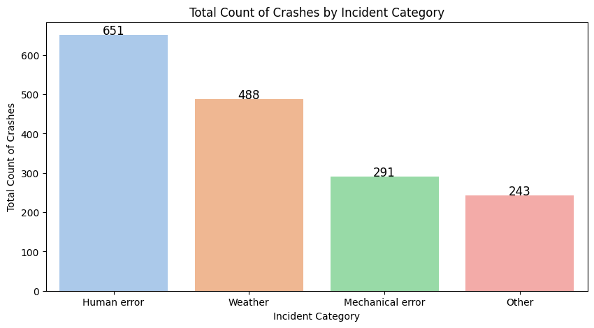

```python
# Plot bar chart
plt.figure(figsize=(10, 5))
sns.barplot(x=category_counts.index, y=category_counts.values, palette="pastel", hue=category_counts.index, legend=False)
plt.xlabel("Incident Category")
plt.ylabel("Total Count of Crashes")
plt.title("Total Count of Crashes by Incident Category")

# Show values on bars
for i, value in enumerate(category_counts.values):
    plt.text(i, value + 1, str(value), ha='center', fontsize=12)

plt.show()
```

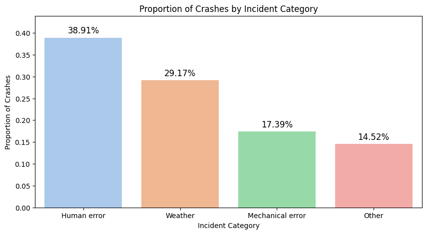

```python
category_proportions = category_counts / category_counts.sum()

# Plot bar chart for proportions
plt.figure(figsize=(10, 5))
sns.barplot(x=category_proportions.index, y=category_proportions.values, hue=category_counts.index, palette="pastel", legend=False)
plt.ylim(0, max(category_proportions.values) + 0.05) # Because initial plot without y-axis limit had the percentage overlapping with border

# Add labels and title
plt.xlabel("Incident Category")
plt.ylabel("Proportion of Crashes")
plt.title("Proportion of Crashes by Incident Category")

# Show values on bars
for i, value in enumerate(category_proportions.values):
    plt.text(i, value + 0.01, f"{value:.2%}", ha='center', fontsize=12)

plt.show()
```

These two graphs plot the NTSB dataset. The first one illustrates the total amount of crashes (y-axis) per incident category (x-axis), whereas the second plot illustrates the proportions of crashes (y-axis) per incident category (x-axis). Results show that human error is the most likely cause of aircraft incidents, followed by weather, mechanical error, and then other causes that fall outside of the three main categories as determined by our manual categorization of the 30 most common words in the “Probable Cause” column.

#### Graph 2 - Yearly Commercial Crash Counts by Causes

```python
#Creating a subset of the commercialflights dataframe that ends in 2023 because the data only goes to August of 2024.
#Therefore is not a true measure of crashes over the whole year.
commercialflights23 = commercialflights[commercialflights['Year']!= 2024].reset_index(drop=True)
commercialflights23
```

|  | EventDate | HighestInjuryLevel | FatalInjuryCount | SeriousInjuryCount | MinorInjuryCount | ProbableCause | Make | Model | AirCraftDamage | WeatherCondition | Operator | Year | IncidentCategory |
| --- | --- | --- | --- | --- | --- | --- | --- | --- | --- | --- | --- | --- | --- |
| 0 | 2023-12-19 18:30:00+00:00 | NaN | 0 | 0 | 0 | bird strike climbout | BOEING | 737 | Substantial | VMC | SOUTHWEST AIRLINES CO | 2023 | Weather |
| 1 | 2023-09-28 08:57:00+00:00 | Serious | 0 | 1 | 0 | malfunctioning brakes service cart | BOEING | 787-8 | NaN | VMC | AMERICAN AIRLINES INC | 2023 | Human error |
| 2 | 2023-09-25 04:00:00+00:00 | Serious | 0 | 4 | 5 | convectively induced turbulence cruise depicte... | AIRBUS | A320-232 | NaN | IMC | JETBLUE AIRWAYS CORP | 2023 | Weather |
| 3 | 2023-09-07 02:32:00+00:00 | Serious | 0 | 1 | 0 | convectively induced turbulence cit | BOEING | 737-9 | NaN | VMC | UNITED AIRLINES INC | 2023 | Weather |
| 4 | 2023-08-18 19:11:00+00:00 | Serious | 0 | 1 | 8 | air turbulence cruise | BOEING | 777-222 | NaN | VMC | UNITED AIRLINES INC | 2023 | Weather |
| ... | ... | ... | ... | ... | ... | ... | ... | ... | ... | ... | ... | ... | ... |
| 1657 | 1987-12-03 13:34:00+00:00 | NaN | 0 | 0 | 0 | drilling cross hole slat track bearing bolt le... | BOEING | 727-243 | Minor | VMC | NaN | 1987 | Other |
| 1658 | 1987-10-09 12:05:00+00:00 | NaN | 0 | 0 | 0 | general aviation visually identify transport f... | MCDONNELL DOUGLAS | DC-9-82 | NaN | VMC | AMERICAN AIRLINES, INC. | 1987 | Other |
| 1659 | 1987-09-28 15:43:00+00:00 | Serious | 0 | 1 | 39 | undetectable air turbulence | LOCKHEED | L-1011 | Minor | VMC | EASTERN AIRLINES | 1987 | Weather |
| 1660 | 1987-06-22 20:39:00+00:00 | NaN | 0 | 0 | 0 | qualified mechanic insure operation brakes pri... | BOEING, BOEING | 737-277, 747SP | Substantial,Substantial | Unknown | AMERICA WEST AIRLINES,UNITED AIRLINES | 1987 | Human error |
| 1661 | 1987-02-27 21:00:00+00:00 | NaN | 0 | 0 | 0 | maintenance personnel adequately examine engin... | BRITISH AEROSPACE | BA146-200A | Substantial | VMC | PACIFIC SOUTHWEST AIRLINES | 1987 | Human error |

1662 rows × 13 columns

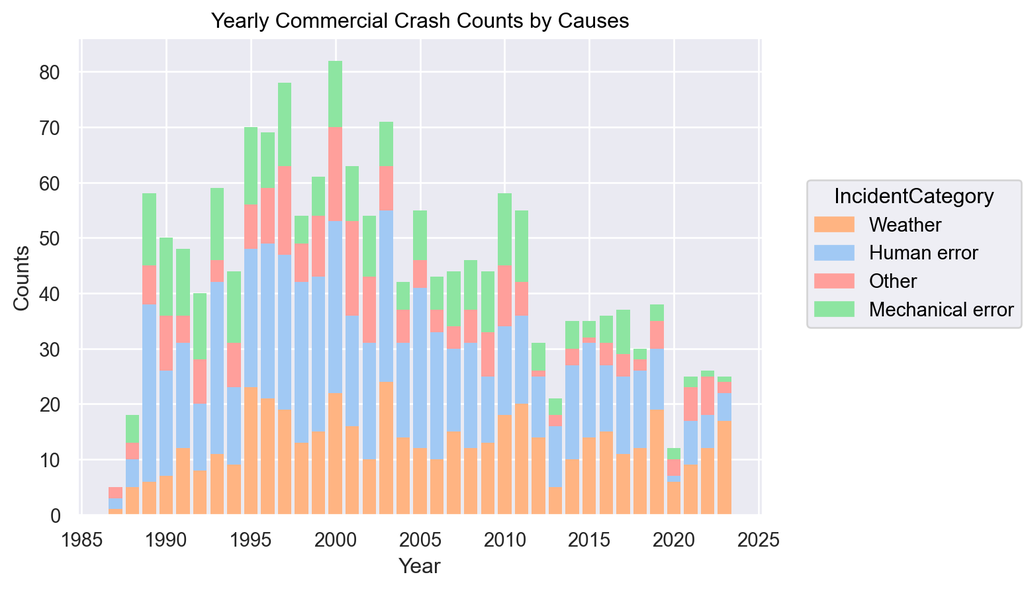

```python
palette = sns.color_palette('pastel')
#for categories colors to be consistent across graphs
matchingcolors = {
    "Human error": palette[0],
    "Weather": palette[1],
    "Mechanical error": palette[2],
    "Other": palette[3]
}

#Creating the stacked bar plot using the incident categories
p = so.Plot(commercialflights23, x="Year", color="IncidentCategory").add(so.Bar(alpha=1), so.Count(), so.Stack()).scale(color=matchingcolors)
p.label(title="Yearly Commercial Crash Counts by Causes", y="Counts")
```

This stacked bar graph displays the total counts of airplane crashes each year, where each total is divided according to the total number of crashes that were caused by weather, human error, mechnical error, or other.

As this graph displays, weather interferences and human errors together account for the majority of crashes each year. The number of crashes due to weather appear to remain roughly constant accross the graph. Crashes due to human error appear to decrease in frequency overall, but maintain a fairly steady proportion of yearly crashes. Failures of the airplane's mechanical components make up a smaller portion of yearly crashes. From 2012 beyond, the number of crashes due to mechanical failures maintains a decreased rate compared to prior years. Since 2012 overall, the total number of commercial airplane crashes remain below 40 per year.

#### Graph 3 - Patterns of Safety Incidents from Human and Mechanical Errors Over Time

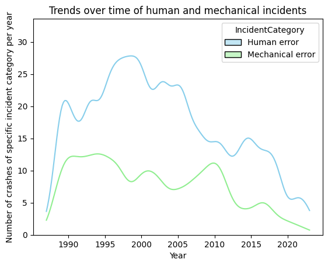

```python
#Trends over time for ntsb dataset, assume data has already has categorization function ran

def trends_over_time(df):
    human_mech_incidents = df[df["IncidentCategory"].isin(['Human error', 'Mechanical error'])]
    human_mech_incidents = human_mech_incidents.assign(year = human_mech_incidents['EventDate'].dt.year)
    human_mech_incidents = human_mech_incidents.drop(human_mech_incidents[human_mech_incidents['year'] == 2024].index)

    #for categories colors to be consistent across graphs
    tomatchprevious = {
        'Human error': 'skyblue',
        'Mechanical error': 'lightgreen'
    }

    ax = sns.histplot(human_mech_incidents, x='year', hue='IncidentCategory', bins=37, kde=True, kde_kws={'bw_adjust': 0.4}, palette=tomatchprevious) #37 number of years in data, with 2024 removed
    ax.containers[0].remove() #generate hisplot and then remove bars to be left with only kde plot
    ax.containers[0].remove()

    plt.xlabel("Year")
    plt.ylabel("Number of crashes of specific incident category per year")
    plt.title("Trends over time of human and mechanical incidents")

trends_over_time(commercialflights)
```

This is a graph that shows trends over time for the ntsb dataset, specifically for incident categories of human error and mechanical error. It is plotted as a kde of a histogram with each bin being a year. A quick look shows that overall there are more human error incidents compared to mechanical ones, although the gap between the yearly frequency of each cause is decreasing as the number of crashes by either cause decreases overall.

### Section 2 - Comparing NTSB and Kaggle Datasets, Their Similarities

In this section, we made use of the count of fatalities in both dataframes to capture their proportions. Through acquiring their proportions we wanted to see how similar fatalities were with our 2 datasets.

#### Graph 4 Exploring the Similarities between Fatalities from the Datasets

```python
#Taking out only crashes where there is a fatal injury in commercial flights to compare with overall flights fatalities
fatalinjurytotal = commercialflights[commercialflights['HighestInjuryLevel'] == 'Fatal'].copy()

#Finding the percentage of fatal injuries amongst other injuries for EDA
fatalinjurytotal['fatalinjurypercent'] = fatalinjurytotal['FatalInjuryCount'] / (fatalinjurytotal['FatalInjuryCount'] + fatalinjurytotal['SeriousInjuryCount'] + fatalinjurytotal['MinorInjuryCount'])
```

```python
fatalinjurytotal.head()
```

|  | EventDate | HighestInjuryLevel | FatalInjuryCount | SeriousInjuryCount | MinorInjuryCount | ProbableCause | Make | Model | AirCraftDamage | WeatherCondition | Operator | Year | IncidentCategory | fatalinjurypercent |
| --- | --- | --- | --- | --- | --- | --- | --- | --- | --- | --- | --- | --- | --- | --- |
| 48 | 2022-12-31 16:39:00+00:00 | Fatal | 1 | 0 | 0 | ramp agent’s cognitive impairment her inconsis... | EMBRAER S A | ERJ 170-200 LR | Minor | VMC | Envoy Air Inc. | 2022 | Mechanical error | 1.000000 |
| 136 | 2019-10-17 17:40:00+00:00 | Fatal | 1 | 1 | 3 | gear manufacturer’s incorrect wiring wheel spe... | Saab | 2000 | Substantial | VMC | Peninsula AviationServices Inc., | 2019 | Human error | 0.200000 |
| 200 | 2018-04-17 11:03:00+00:00 | Fatal | 1 | 8 | 125 | low cycle crack dovetail fan blade no 13 fan b... | BOEING | 737 7H4 | Substantial | VMC | SOUTHWEST AIRLINES CO | 2018 | Human error | 0.007463 |
| 594 | 2009-02-12 21:17:00+00:00 | Fatal | 50 | 0 | 0 | captain’s inappropriate response activation st... | BOMBARDIER INC | DHC-8-402 | Destroyed | VMC | COLGAN AIR INC | 2009 | Weather | 1.000000 |
| 710 | 2006-08-27 06:07:00+00:00 | Fatal | 49 | 1 | 0 | crewmembers available cues aids identify locat... | Bombardier, Inc. | CRJ-100 | Destroyed | VMC | COMAIR INC | 2006 | Weather | 0.980000 |

```python
#carrying out a t-test
t_val, p_val = ttest_ind(fatalinjurytotal['FatalInjuryCount'], overallflights['Fatalities'])
#look at results
t_val, p_val
```

```
(np.float64(0.8706269704128076), np.float64(0.384121624551906))
```

```python
#this is code is accessed from ChatGPT, with some changes. We are exploring how similar the fatality percentages are between the two datasets through a histogram visualization

# Create histograms for both datasets
commercialhistogram, bins1 = np.histogram(fatalinjurytotal['fatalinjurypercent'].dropna(), bins=10, range=(0, 100))
overallhistogram, bins2 = np.histogram(overallflights['FatalitiesPercent'].dropna(), bins=10, range=(0, 100))

# Normalize histograms to get distributions
commercialhistogram = commercialhistogram / commercialhistogram.sum()
overallhistogram = overallhistogram / overallhistogram.sum()

# Calculate histogram intersection
intersection = np.sum(np.minimum(commercialhistogram, overallhistogram))

#A histogram intersection is from 0 - 1, with 0 being least and 1 being most similar
print(f"Histogram Intersection: {intersection}")
```

```
Histogram Intersection: 1.0
```

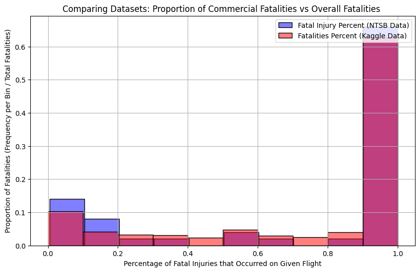

```python
# Drop NaN values from both datasets to avoid issues
df1_clean = fatalinjurytotal['fatalinjurypercent'].dropna()
df2_clean = overallflights['FatalitiesPercent'].dropna()

# Create a figure and axis
fig, ax = plt.subplots(figsize=(10, 6))

# Plot the first dataset with proportions on the same y-axis
sns.histplot(df1_clean, bins=10, kde=False, color='blue', label='Fatal Injury Percent (NTSB Data)', alpha=0.5, stat='probability', ax=ax)
sns.histplot(df2_clean, bins=10, kde=False, color='red', label='Fatalities Percent (Kaggle Data)', alpha=0.5, stat='probability', ax=ax)

# Set labels
ax.set_xlabel('Percentage of Fatal Injuries that Occurred on Given Flight')
ax.set_ylabel('Proportion of Fatalities (Frequency per Bin / Total Fatalities)')

# Add a title and grid
plt.title('Comparing Datasets: Proportion of Commercial Fatalities vs Overall Fatalities ')
ax.grid(True)

# Adding a single legend that combines both datasets
ax.legend(loc='upper right')

# Show the plot
plt.show()
```

This graph plots the histograms of the fatality percentages of both dataframes.

# Ethics & Privacy

Dataset #1 comes from the National Transportation Safety Board, which is a federal agency that investigates U.S. aviation accidents. Each accident observation has a docket report linked to it which contains flight crew members’ full names and ages. As this personally identifiable information is not relevant to our analysis of airplane crashes, we did not include the data column with the links to the reports. Additionally, we removed the NTSB identification numbers for the incidents so that the reports can not be easily accessed. However, since all information on NTSB crashes is publicly available, we acknowledge that the names of flight crew members could still be accessed. Our second dataset, accessed from Kaggle, does not contain any personally identifiable information.

An additional privacy concern regarding our datasets includes the handling of data on the number of injuries and fatalities in plane crashes, which, in combination with the date and airline operator of the crashes, could possibly be linked to certain passengers or crew members. We deem the privacy risk to be low, in part due to our choice to remove the locations of the crashes.

A concern of possible bias we identify is the current presence of strong public opinions regarding the safety of particular U.S. airlines. This has followed the recent significant media attention towards airplane crashes, driving a sentiment of public fear that plane crashes have been increasing. Additionally, our objective analysis of plane crashes across different airlines does not intend to direct distrust or any otherwise negative publicity towards any commercial airline, but rather is concerned with investigating flight accidents from a safety standpoint.

# Discussion and Conclusion

This project explored how the trends in global commercial aircraft accidents have changed from the 1980's until now. We hypothesized that there has been a decline in mechanical failures over time as a result of advancements in technology. Secondly, we predicted that there has not been a change in the rate of plane crashes caused by pilot error. Thirdly, we hypothesized that there has been no change in crashes due to weather due to storms and low visibility out of human control consistently posing safety risks.

Our graphs indicate that the frequency of aviation accidents in general have decreased over time. Looking specifically at Graphs 2 and 3, the totals are going down overall, as explained in our analysis. Our hypothesis that the human error crash rate would stay the same is not supported. For the mechanical and weather parts of our hypothesis, our hypothesis was supported, since there has been a decrease over time for mechanical incidents and a steady trend for weather incidents.

A potential explanation of why crashes due to human error have decreased is that perhaps operating guidelines for planes have been consistently updated to increase effectiveness of procedures leading to fewer human errors overall. Another explanation may be that advancements in aviation technology have lead to human errors being correctable or less serious in that they do not result as crashes as often. Explaining the decrease in mechanical errors and the consistent occurence of crashes due to adverse weather, our reasoning underlying our hypothesis provides a reasonable explanation. That is, that better manufacturing and technology has lead to increased reliability and durability of the mechanical components of airplanes, and that weather remains a constant issue to deal with when flying.

Ultimately, although public sentiment as of early 2025 reflects an increased doubt in the safety of flying due to sequential airplane crashes across the U.S. receiving extensive media attention, our findings show that that fear is unfounded since the rates of yearly crashes has been decreasing.

One limitation of our project is that our approach to categorizing the probable causes of the commercial flights into our categories of interest resulted in the specificity of details being reduced. This led to information on the types of human errors, weather events, and part failures not being considered. Additionally, it resulted in a substantial number of crashes being categorized as other.

Future research is needed to explore what types of human errors, mechanical failures, and weather conditions, tend to contribute to more fatal crashes, and which types happen most overall. Looking more into this will allow more attention to be directed to aspects of commercial aviation that need more development so as to reduce the rate and severity of aviation accidents and to continue to make flying safer overall.

# Team Contributions

- Naomi: Graph 2 and its description and analysis, ethics & privacy, collaborated with Austin on discussion and conclusion, and part of dataset 1 cleaning
- Austin: Graph 3 and its description and analysis, overall discussion and conclusion, and part of dataset 1 cleaning
- Alice: Graph 4 and its description and analysis, wrote slides, coordinated meetings, dataset 2 cleaning
- Julianne: Graph 1 and its description and analysis, abstract, some slide visual designs, and part of dataset 1 cleaning
- Kiara: Graph 0 (this graph was removed from final project due to lack of relevancy) plot both datasets to show how fatality data changes throughout the years from 1987 - 2023, part of dataset 2 cleaning, and record presentation video